# Camp Polk Flow Actions & RM 8.5 Temperature Compliance

When is a flow increase effective, how much is needed, and how early must it start?

June 12, 2026

## Background

> **Q1: How much Camp Polk flow is needed to keep RM 8.5 7DADM at or below 20°C?**

> **Q2: How early does that flow action need to start — and does waiting cost compliance?**

> **Q3: When in the summer season is flow management actually effective, and when does atmospheric heating dominate regardless of what Camp Polk releases?**

## Settings

```r
target_C       <- 20.0
analysis_start <- as.Date("2024-06-01")
analysis_end   <- as.Date("2024-09-30")
lead_days_vec  <- c(1, 3, 7)
model_dir      <- here("output")
```

## 1. Flow, Air Temperature & Stream Temperature

Before stepping through the model-based counterfactual analysis, it helps to see how the three key variables — Camp Polk flow, air temperature, and RM 8.5 stream temperature — relate to each other across the warm season. The raw paired record from 2012 to 2025 tells a nuanced story: air temperature is the dominant driver of stream temperature, and flow modulates it.

A simple scatter of flow versus stream temperature would suggest a negative relationship: higher flows tend to coincide with cooler water. But that pattern is largely a seasonal artifact. Camp Polk flows naturally peak in late May–June with snowmelt and then decline through August as the snowpack is exhausted and irrigation withdrawals intensify. Air temperatures follow the opposite trajectory — rising through July and August and driving stream warming independently of flow. The apparent flow-temperature correlation is, to a meaningful degree, a proxy for time of year.

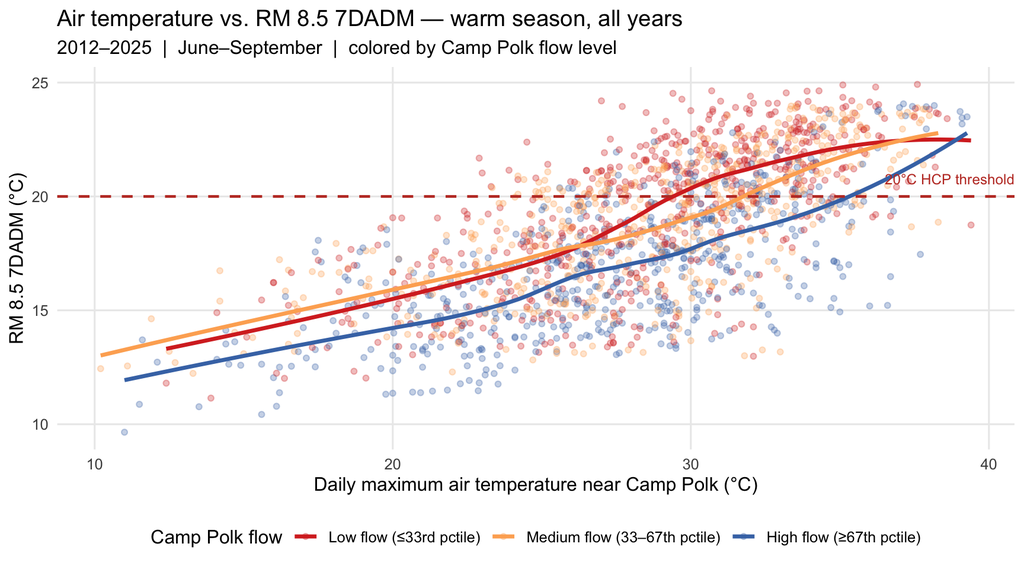

```r
ggplot(flow_temp_joined, aes(x = air_max, y = dadm_7, color = flow_bin)) +
  geom_point(alpha = 0.30, size = 1.4) +
  geom_smooth(method = "loess", span = 0.7, se = FALSE, linewidth = 1.2) +
  geom_hline(yintercept = 20, linetype = "dashed",
             color = "#c0392b", linewidth = 0.8) +
  annotate("text", x = Inf, y = 20.4, label = "20°C HCP threshold",
           hjust = 1, vjust = -0.3, color = "#c0392b", size = 3.2) +
  scale_color_manual(values = flow_bin_colors, name = "Camp Polk flow") +
  labs(
    title    = "Air temperature vs. RM 8.5 7DADM — warm season, all years",
    subtitle = "2012–2025  |  June–September  |  colored by Camp Polk flow level",
    x        = "Daily maximum air temperature near Camp Polk (°C)",
    y        = "RM 8.5 7DADM (°C)"
  ) +
  theme_minimal(base_size = 12) +
  theme(panel.grid.minor = element_blank(), legend.position = "bottom")
```

Figure 2 shows the same data with axes swapped — flow on the x-axis as one might expect — but with air temperature shown as a continuous color scale. Within each month panel, it is the hottest air temperature days (red) that drive the highest stream temperatures, not simply the low-flow days. The flow-temperature gradient within a month is real but secondary; air temperature is doing most of the work.

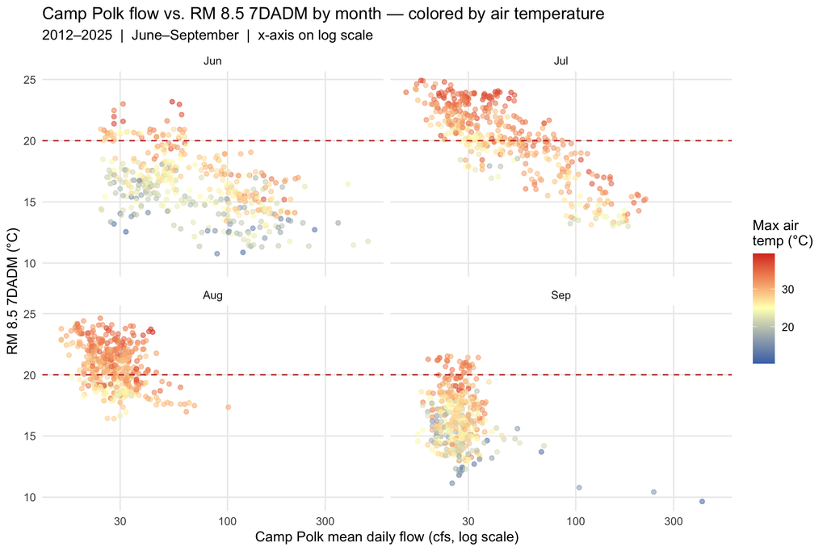

```r
ggplot(flow_temp_joined, aes(x = flow_cfs, y = dadm_7)) +
  geom_point(aes(color = air_max), alpha = 0.55, size = 1.4) +
  geom_hline(yintercept = 20, linetype = "dashed", color = "#c0392b") +
  scale_x_log10(labels = scales::comma) +
  scale_color_gradient2(low = "#4575b4", mid = "#ffffbf", high = "#d73027",
                        midpoint = 25, name = "Max air\ntemp (°C)") +
  facet_wrap(~month_name, ncol = 2) +
  labs(
    title    = "Camp Polk flow vs. RM 8.5 7DADM by month — colored by air temperature",
    subtitle = "2012–2025  |  June–September  |  x-axis on log scale",
    x        = "Camp Polk mean daily flow (cfs, log scale)",
    y        = "RM 8.5 7DADM (°C)"
  ) +
  theme_minimal(base_size = 11) +
  theme(panel.grid.minor = element_blank(), legend.position = "right")
```

The practical takeaway from both figures: **flow management is most effective when air temperatures are in the moderate range — roughly 20–28°C — where cool upstream water can still move the needle on RM 8.5 temperatures.** When air temperatures are extreme, even sustained high flows provide limited relief. The model-based analysis that follows quantifies exactly where that boundary falls and which historical exceedance events fall on which side of it.

## 2. Historical RM 8.5 Exceedances

```r
# Full-history daily max and 7DADM at RM 8.5
# TODO: use whychusModel::rm_8_5_historical
rm85_dadm_all <- whychusModel::rm_8_5_historical |>
  filter(statistic %in% c("max", "7DADM")) |>
  pivot_wider(id_cols = date, names_from = "statistic", values_from = "temperature") |>
  rename(tmax = max,
         dadm_7 = `7DADM`) |>
  mutate(date = as.Date(date))

# 2024 analysis window
rm85_daily_max <- rm85_dadm_all |>
  filter(date >= analysis_start, date <= analysis_end)

# Anchor event: peak 7DADM exceedance in 2024
anchor_row  <- rm85_daily_max |> filter(dadm_7 > target_C) |> slice_max(dadm_7, n = 1)
anchor_date <- anchor_row$date
anchor_dadm <- round(anchor_row$dadm_7, 1)
anchor_year <- year(anchor_date)
```

From 2012 through 2025, RM 8.5 has exceeded the 20°C HCP threshold on **599** days. Exceedances are concentrated in the mid-June through August window and vary considerably by year, with some summers largely compliant and others sustaining multi-week exceedance periods.

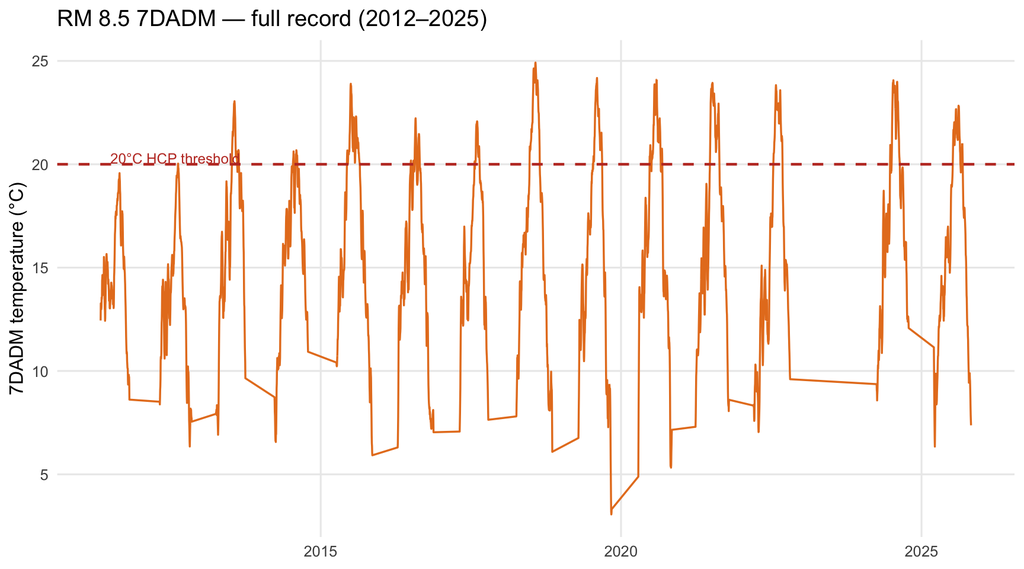

```r
exceed_ts <- rm85_dadm_all |>
  filter(!is.na(dadm_7))

ggplot(exceed_ts, aes(x = date, y = dadm_7)) +
  geom_line(color = "#e67e22", linewidth = 0.6) +
  geom_hline(yintercept = target_C, linetype = "dashed",
             color = "#c0392b", linewidth = 0.8) +
  annotate("text",
           x    = min(exceed_ts$date, na.rm = TRUE) + 60,
           y    = target_C + 0.3,
           label = "20°C HCP threshold",
           hjust = 0, color = "#c0392b", size = 3.2) +
  labs(title    = "RM 8.5 7DADM — full record (2012–2025)",
       x = NULL, y = "7DADM temperature (°C)") +
  theme_minimal(base_size = 12) +
  theme(panel.grid.minor = element_blank())
```

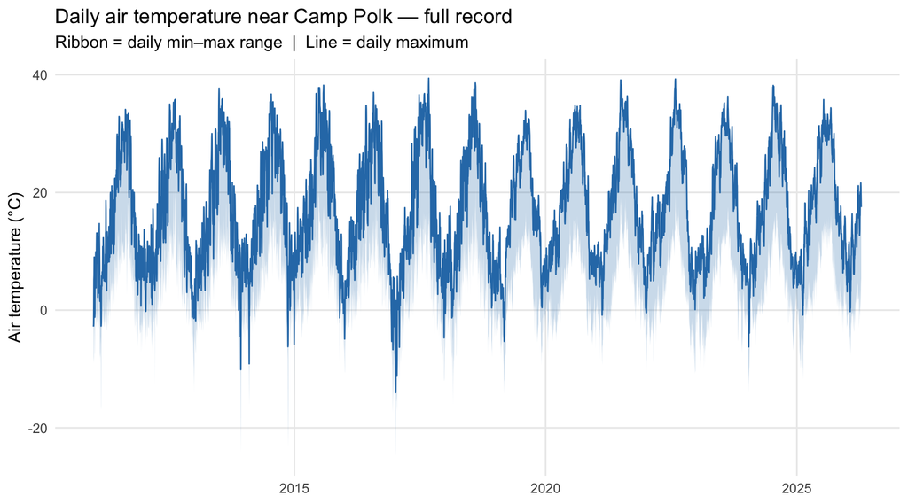

**Figure 4.** Historical daily air temperature near Camp Polk (2 m). Blue ribbon = daily min–max range; dark line = daily maximum. Values averaged across available forecast lead times for each calendar date.

```r
air_temp_hist <- all_historical_forecasts |>
  filter(variable %in% c("temperature_2m_max", "temperature_2m_min")) |>
  group_by(valid_date, variable) |>
  summarise(value = mean(value, na.rm = TRUE), .groups = "drop") |>
  pivot_wider(names_from = variable, values_from = value) |>
  filter(!is.na(temperature_2m_max), !is.na(temperature_2m_min))

ggplot(air_temp_hist, aes(x = valid_date)) +
  geom_ribbon(aes(ymin = temperature_2m_min, ymax = temperature_2m_max),
              fill = "#2c7bb6", alpha = 0.25) +
  geom_line(aes(y = temperature_2m_max), color = "#2c7bb6", linewidth = 0.5) +
  labs(title    = "Daily air temperature near Camp Polk — full record",
       subtitle = "Ribbon = daily min–max range  |  Line = daily maximum",
       x = NULL, y = "Air temperature (°C)") +
  theme_minimal(base_size = 12) +
  theme(panel.grid.minor = element_blank())
```

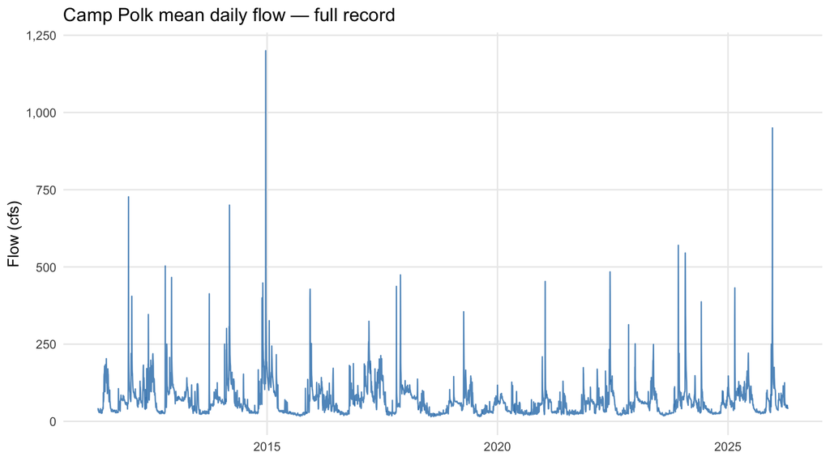

**Figure 5.** Historical mean daily Camp Polk flow (OWRD gage).

```r
flow_hist <- camp_polk_flow_historical |>
  filter(statistic == "mean", !is.na(flow_cfs))

ggplot(flow_hist, aes(x = date, y = flow_cfs)) +
  geom_line(color = "#2c7bb6", linewidth = 0.5, alpha = 0.8) +
  scale_y_continuous(labels = scales::comma) +
  labs(title = "Camp Polk mean daily flow — full record",
       x = NULL, y = "Flow (cfs)") +
  theme_minimal(base_size = 12) +
  theme(panel.grid.minor = element_blank())
```

## 3. A 2024 Exceedance — Setting the Stage

```r
# TODO: this could potentially be better -- current r2 is 0.2
# Camp Polk flow → temperature relationship (warm season, Jun–Sep).
# Used as a delta: given a flow change from q_obs to q, the model estimates how much
# Camp Polk 7DADM changes. The observed temperature is preserved as the baseline so that
# the thermal state of the system on each run date is respected.

# Agree that this is an area of improvement, some thoughts include - where would the flow action be occurring, assumping TSID diversion. We could model the change in temperature resulting from flow left instream in the reach between TSID and Camp Polk rather than the direct relationship between flow and temperature at CP.

cp_flow_temp_hist <- camp_polk_flow_historical |>
  filter(statistic == "mean") |> select(date, flow_cfs) |>
  inner_join(
    camp_polk_temperature_historical |>
      filter(statistic == "7DADM") |>
      mutate(date = as.Date(date)) |>
      select(date, cp_7dadm = temperature),
    by = "date"
  ) |>
  filter(month(date) %in% 6:9, !is.na(flow_cfs), !is.na(cp_7dadm))

cp_temp_lm <- lm(cp_7dadm ~ log(flow_cfs), data = cp_flow_temp_hist)
summary(cp_temp_lm)
```

```
##
## Call:
## lm(formula = cp_7dadm ~ log(flow_cfs), data = cp_flow_temp_hist)
##
## Residuals:
##     Min      1Q  Median      3Q     Max
## -6.1062 -1.6781  0.4277  1.7024  4.9062
##
## Coefficients:
##               Estimate Std. Error t value Pr(>|t|)
## (Intercept)   22.06589    0.33177   66.51   <2e-16 ***
## log(flow_cfs) -1.87800    0.09018  -20.83   <2e-16 ***
## ---
## Signif. codes:  0 '***' 0.001 '**' 0.01 '*' 0.05 '.' 0.1 ' ' 1
##
## Residual standard error: 2.129 on 1580 degrees of freedom
## Multiple R-squared:  0.2154, Adjusted R-squared:  0.2149
## F-statistic: 433.7 on 1 and 1580 DF,  p-value: < 2.2e-16
```

```r
# Returns the model-predicted temperature at flow q (used only to compute deltas)
cp_temp_at_flow <- function(q) {
  as.numeric(predict(cp_temp_lm, newdata = data.frame(flow_cfs = pmax(q, 1))))
}

# Adjust observed temperature by the model-predicted change from baseline flow q_obs to q
cp_temp_delta <- function(t_obs, q, q_obs) {
  t_obs + (cp_temp_at_flow(q) - cp_temp_at_flow(q_obs))
}
```

The peak 7DADM in summer 2024 occurred on **July 14, 2024**, reaching **24.1°C** — 4.1°C above the 20°C standard. This event anchors the worked example in the next section.

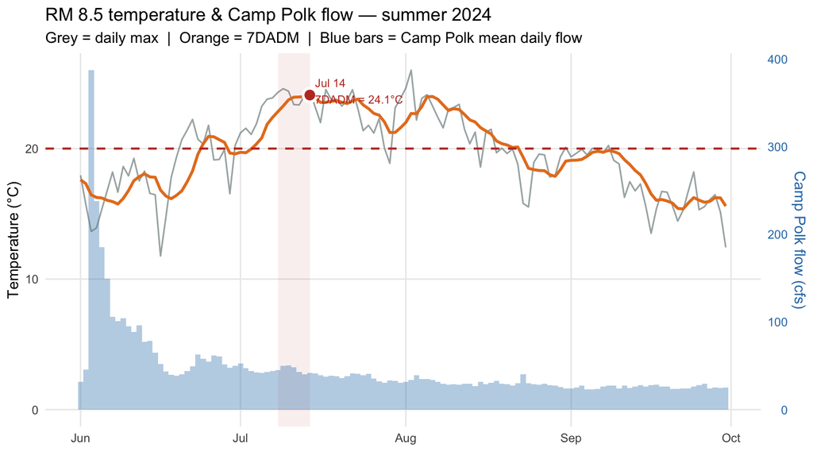

**Figure 6.** RM 8.5 temperature and Camp Polk flow over summer 2024. Orange line = 7DADM; grey line = daily max; blue bars = mean daily Camp Polk flow (right axis). The red shaded band highlights the 7-day averaging window that produced the peak exceedance. The dashed red line marks the 20°C HCP threshold.

```r
band_start     <- anchor_date - 6
cp_flow_window <- camp_polk_flow_historical |>
  filter(statistic == "mean", date >= analysis_start, date <= analysis_end)
flow_scale <- max(cp_flow_window$flow_cfs, na.rm = TRUE) /
              max(rm85_daily_max$tmax, na.rm = TRUE)

rm85_daily_max |>
  ggplot(aes(x = date)) +
  annotate("rect", xmin = band_start, xmax = anchor_date,
           ymin = -Inf, ymax = Inf, fill = "#c0392b", alpha = 0.08) +
  geom_col(data = cp_flow_window,
           aes(x = date, y = flow_cfs / flow_scale),
           fill = "#2c7bb6", alpha = 0.35, width = 1) +
  geom_line(aes(y = tmax),   color = "#7f8c8d", linewidth = 0.6, alpha = 0.7) +
  geom_line(aes(y = dadm_7), color = "#e67e22", linewidth = 1.1) +
  geom_hline(yintercept = target_C, linetype = "dashed",
             color = "#c0392b", linewidth = 0.8) +
  annotate("point", x = anchor_date, y = anchor_dadm,
           shape = 21, size = 4, fill = "#c0392b", color = "white", stroke = 1.5) +
  annotate("text", x = anchor_date + 1, y = anchor_dadm + 0.3,
           label = sprintf("%s\n7DADM = %.1f°C", format(anchor_date, "%b %d"), anchor_dadm),
           hjust = 0, color = "#c0392b", size = 3.2) +
  scale_y_continuous(
    name     = "Temperature (°C)",
    sec.axis = sec_axis(~ . * flow_scale, name = "Camp Polk flow (cfs)",
                        labels = scales::comma)
  ) +
  labs(title    = "RM 8.5 temperature & Camp Polk flow — summer 2024",
       subtitle = "Grey = daily max  |  Orange = 7DADM  |  Blue bars = Camp Polk mean daily flow",
       x = NULL) +
  theme_minimal(base_size = 12) +
  theme(panel.grid.minor   = element_blank(),
        axis.title.y.right = element_text(color = "#2c7bb6"),
        axis.text.y.right  = element_text(color = "#2c7bb6"))
```

## 4. What Flow Would Have Prevented the Exceedance?

For each forecast lead (1, 3, and 7 days before the anchor event), air temperature and cloud cover are fixed at their observed historical values. Camp Polk flow is swept across the 5th–95th percentile of the observed record (`cp_flow_mean` and `cp_flow_m1` swept together — a sustained 2-day flow scenario), and Camp Polk water temperature (`cp_7dadm`, `cp_7dadm_m1`) is co-varied with flow using a log-linear regression fit to warm-season historical data (cp_7dadm = 22.07 + -1.88 × log(flow), R² = 0.22). The crossing point at 20°C is the minimum sustained flow estimated to prevent exceedance at that lead.

```r
get_wx <- function(d, var, k) {
  v <- all_historical_forecasts |>
    filter(valid_date == d, variable == var) |>
    filter(lead_days == k) |>
    pull(value)
    # summarise(out = fn(value, na.rm = TRUE)) |>
    #pull(out)
  if (length(v) == 0 || is.nan(v)) NA_real_ else v
}
#first_val <- function(x) if (length(x) > 0) x[[1]] else NA_real_

base_feats <- map(lead_days_vec, function(k) {
  run_date <- anchor_date - k
  list(
    k           = k,
    run_date    = run_date,
    obs_flow    = camp_polk_flow_historical |>
                    filter(statistic == "mean", date == run_date) |> pull(flow_cfs),
    cp_7dadm    = camp_polk_temperature_historical |>
                    filter(statistic == "7DADM", date == run_date) |> pull(temperature),
    Julian      = yday(run_date),
    air_max     = get_wx(run_date,     "temperature_2m_max", k),
    air_min     = get_wx(run_date,     "temperature_2m_min", k),
    cloud_pct   = get_wx(run_date,     "cloud_cover_mean", k),
    cp_7dadm_m1 = camp_polk_temperature_historical |>
                    filter(statistic == "7DADM", date == run_date - 1) |> pull(temperature),
    air_max_m1  = get_wx(run_date - 1, "temperature_2m_max", k),
    air_min_m1  = get_wx(run_date - 1, "temperature_2m_min", k),
    dadm_m1     = rm85_dadm_all |> filter(date == run_date - 1) |> pull(dadm_7)
  )
})
```

```r
flow_range <- quantile(camp_polk_flow_historical$flow_cfs, c(0.05, 0.95), na.rm = TRUE)
flow_grid  <- seq(flow_range[1], flow_range[2], length.out = 300)

sweep_df <- map_dfr(base_feats, function(bf) {
  rf <- readRDS(file.path(model_dir, sprintf("rm85_rf_7dadm_lead%d.rds", bf$k)))

  # Guard against empty gauge lookups (no record for that exact date → numeric(0))
  scalar <- function(x) if (length(x) == 0) NA_real_ else x[[1]]

  # Vectorise over entire flow grid at once so predict.all=TRUE returns a
  # 300-row × 500-tree matrix in a single call (faster than looping)
  calc_cp_7dadm    <- cp_temp_delta(scalar(bf$cp_7dadm),    flow_grid, scalar(bf$obs_flow))
  calc_cp_7dadm_m1 <- cp_temp_delta(scalar(bf$cp_7dadm_m1), flow_grid, scalar(bf$obs_flow))

  feat_mat <- data.frame(
    cp_flow_mean = flow_grid,
    cp_7dadm     = calc_cp_7dadm,
    Julian       = scalar(bf$Julian),
    air_max      = scalar(bf$air_max),
    air_min      = scalar(bf$air_min),
    cloud_pct    = scalar(bf$cloud_pct),
    cp_flow_m1   = flow_grid,
    cp_7dadm_m1  = calc_cp_7dadm_m1,
    air_max_m1   = scalar(bf$air_max_m1),
    air_min_m1   = scalar(bf$air_min_m1),
    dadm_m1      = scalar(bf$dadm_m1)
  )

  preds_all <- predict(rf, newdata = feat_mat, predict.all = TRUE)
  pred_sd   <- apply(preds_all$individual, 1, sd)

  tibble(
    lead_days     = bf$k,
    run_date      = bf$run_date,
    obs_cp_7dadm  = scalar(bf$cp_7dadm),
    calc_cp_7dadm = calc_cp_7dadm,
    obs_flow      = scalar(bf$obs_flow),
    flow_cfs      = flow_grid,
    pred_7dadm    = preds_all$aggregate,
    pred_sd       = pred_sd,
    ci_lower      = preds_all$aggregate - 1.96 * pred_sd,
    ci_upper      = preds_all$aggregate + 1.96 * pred_sd
  )
})

# "for each forecast horizon, what is the minimum flow needed to meet the temperature target, and how far are we from that flow today?"
threshold_df <- sweep_df |>
  group_by(lead_days) |>
  mutate(crosses = any(pred_7dadm <= target_C)) |>
  filter(if_else(crosses, pred_7dadm <= target_C, pred_7dadm == min(pred_7dadm))) |>
  slice_min(flow_cfs, n = 1) |>
  ungroup() |>
  mutate(flow_gap = round(flow_cfs - obs_flow))

# Conservative threshold: minimum flow where even the upper CI (pred + 1.96*sd)
# drops to or below target — i.e., confident the action achieves compliance
threshold_df_conservative <- sweep_df |>
  group_by(lead_days) |>
  mutate(crosses_conservative = any(ci_upper <= target_C)) |>
  filter(if_else(crosses_conservative, ci_upper <= target_C, ci_upper == min(ci_upper))) |>
  slice_min(flow_cfs, n = 1) |>
  ungroup() |>
  mutate(flow_gap = round(flow_cfs - obs_flow))

# what does the model predict at current flow?
obs_pred_df <- sweep_df |>
  group_by(lead_days) |>
  slice_min(abs(flow_cfs - obs_flow), n = 1) |>
  ungroup()
```

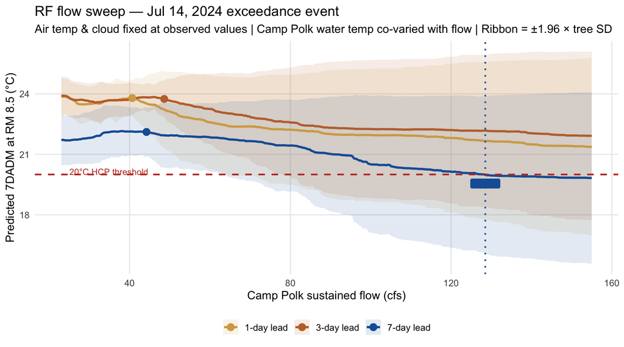

**Figure 7.** Predicted RM 8.5 7DADM as a function of sustained Camp Polk flow at each forecast lead, with all non-flow conditions fixed at their observed values for the anchor event. Dashed red line = 20°C HCP threshold. Vertical dotted lines = minimum sustained flow needed to reach the threshold (shown only where achievable). Filled circles = model prediction at the flow that actually occurred on each run date.

Table 2. Minimum Camp Polk flow to hold RM 8.5 7DADM at or below 20.0°C by forecast lead. ‘Point est.’ = where the RF mean prediction crosses 20.0°C. ‘Conservative’ = where the upper bound of the ±1.96 SD tree interval also crosses 20.0°C (higher confidence the action achieves compliance).

| Days before exceedance | Action start date | Observed flow (cfs) | Point est. flow needed (cfs) | Conservative flow needed (cfs) | Threshold reachable |
| --- | --- | --- | --- | --- | --- |
| 1 | Jul 13, 2024 | 40 | 154 | Not achievable | No — atm. driver |
| 3 | Jul 11, 2024 | 48 | 155 | Not achievable | No — atm. driver |
| 7 | Jul 07, 2024 | 44 | 129 | Not achievable | Yes |

```r
lead_colors <- c("1" = "#D4A853", "3" = "#C07038", "7" = "#185FA5")
lead_labels <- c("1" = "1-day lead", "3" = "3-day lead", "7" = "7-day lead")
threshold_crossings <- filter(threshold_df, crosses)

ggplot(sweep_df, aes(x = flow_cfs, group = factor(lead_days),
                     color = factor(lead_days), fill = factor(lead_days))) +
  geom_ribbon(aes(ymin = ci_lower, ymax = ci_upper), alpha = 0.12, color = NA) +
  geom_line(aes(y = pred_7dadm), linewidth = 1.1) +
  geom_hline(yintercept = target_C, linetype = "dashed",
             color = "#c0392b", linewidth = 0.8) +
  annotate("text", x = flow_range[[1]] + 2, y = target_C + 0.15,
           label = paste0(target_C, "°C HCP threshold"),
           hjust = 0, color = "#c0392b", size = 3.2) +
  { if (nrow(threshold_crossings) > 0) list(
      geom_vline(data = threshold_crossings,
                 aes(xintercept = flow_cfs, color = factor(lead_days)),
                 linetype = "dotted", linewidth = 0.8, show.legend = FALSE),
      geom_label(data = threshold_crossings,
                 aes(x = flow_cfs, y = target_C - 0.45,
                     label = sprintf("%.0f cfs", flow_cfs),
                     color = factor(lead_days)),
                 size = 3, show.legend = FALSE, label.padding = unit(0.15, "lines"))
  )} +
  geom_point(data = obs_pred_df,
             aes(x = flow_cfs, y = pred_7dadm, color = factor(lead_days)),
             size = 3.5, shape = 16) +
  { if (nrow(threshold_crossings) == 0)
      annotate("text", x = mean(flow_range), y = target_C - 0.5,
               label = "Threshold not achievable within observed flow range\n(atmospheric driver dominates)",
               hjust = 0.5, color = "grey40", size = 3.2, fontface = "italic")
  } +
  scale_color_manual(values = lead_colors, labels = lead_labels, name = NULL) +
  scale_fill_manual( values = lead_colors, labels = lead_labels, name = NULL) +
  scale_x_continuous(labels = scales::comma) +
  labs(title    = sprintf("RF flow sweep — %s exceedance event", format(anchor_date, "%b %d, %Y")),
       subtitle = "Air temp & cloud fixed at observed values | Camp Polk water temp co-varied with flow | Ribbon = ±1.96 × tree SD",
       x = "Camp Polk sustained flow (cfs)", y = "Predicted 7DADM at RM 8.5 (°C)") +
  theme_minimal(base_size = 12) +
  theme(panel.grid.minor = element_blank(), legend.position = "bottom")
```

**Key finding:** Acting **7 days** before the exceedance, a sustained Camp Polk flow of **129 cfs** (+84 cfs from observed) is estimated to hold RM 8.5 7DADM at or below 20.0°C.

## 5. Does This Pattern Hold Across Years?

The worked example above describes one event. This section runs the same RF flow sweep — with Camp Polk water temperature co-varied with flow — across all **599 historical exceedance days** (2012–2025) to ask: for how many events is flow management effective, and does effectiveness depend on when in the summer the exceedance occurs?

```r
exceed <- rm85_dadm_all |>
  filter(dadm_7 >= target_C, !is.na(dadm_7)) |>
  mutate(year = year(date), julian = yday(date))

flow_mean_lkp <- camp_polk_flow_historical |>
  filter(statistic == "mean") |> select(date, flow_cfs)

cp_temp_lkp <- camp_polk_temperature_historical |>
  filter(statistic == "7DADM") |>
  mutate(date = as.Date(date)) |> select(date, cp_7dadm = temperature)

# TODO = flagging this as a potential issue since it's not grouping
# by lead days
wx_daily <- all_historical_forecasts |>
  group_by(valid_date, variable) |>
  summarise(value = mean(value, na.rm = TRUE), .groups = "drop") |>
  pivot_wider(names_from = variable, values_from = value)

flow_range_hist <- quantile(camp_polk_flow_historical$flow_cfs, c(0.05, 0.95), na.rm = TRUE)
flow_grid_hist  <- seq(flow_range_hist[1], flow_range_hist[2], length.out = 100)

models_hist <- map(lead_days_vec, function(k) {
  readRDS(file.path(model_dir, sprintf("rm85_rf_7dadm_lead%d.rds", k)))
}) |> set_names(lead_days_vec)
```

```r
all_feats <- expand_grid(exceedance_date = exceed$date, lead_days = lead_days_vec) |>
  mutate(run_date = exceedance_date - lead_days,
         julian   = yday(exceedance_date),
         year     = year(exceedance_date)) |>
  left_join(flow_mean_lkp |> rename(run_date = date, cp_flow_mean = flow_cfs), by = "run_date") |>
  left_join(flow_mean_lkp |> mutate(run_date = date + 1) |>
              rename(cp_flow_m1 = flow_cfs) |> select(-date), by = "run_date") |>
  left_join(cp_temp_lkp |> rename(run_date = date), by = "run_date") |>
  left_join(cp_temp_lkp |> mutate(run_date = date + 1) |>
              rename(cp_7dadm_m1 = cp_7dadm) |> select(-date), by = "run_date") |>
  left_join(wx_daily |> rename(exceedance_date = valid_date), by = "exceedance_date") |>
  left_join(wx_daily |> mutate(exceedance_date = valid_date + 1) |>
              rename(air_max_m1 = temperature_2m_max, air_min_m1 = temperature_2m_min) |>
              select(exceedance_date, air_max_m1, air_min_m1), by = "exceedance_date") |>
  rename(air_max = temperature_2m_max, air_min = temperature_2m_min,
         cloud_pct = cloud_cover_mean) |>
  left_join(rm85_dadm_all |> mutate(run_date = date + 1) |>
              rename(dadm_m1 = dadm_7) |> select(run_date, dadm_m1), by = "run_date") |>
  filter(complete.cases(pick(cp_flow_mean, cp_7dadm, air_max, dadm_m1)))

# One predict() call per model — vectorized across all events
sweep_results <- map_dfr(lead_days_vec, function(k) {
  rf      <- models_hist[[as.character(k)]]
  feats_k <- all_feats |> filter(lead_days == k)
  n       <- nrow(feats_k)

  flow_rep          <- rep(flow_grid_hist, n)
  obs_flow_rep      <- rep(feats_k$cp_flow_mean,  each = length(flow_grid_hist))
  obs_cp_7dadm_rep  <- rep(feats_k$cp_7dadm,      each = length(flow_grid_hist))
  obs_cp_7dadm_m1_rep <- rep(feats_k$cp_7dadm_m1, each = length(flow_grid_hist))

  big_mat <- feats_k |>
    slice(rep(seq_len(n), each = length(flow_grid_hist))) |>
    mutate(
      cp_flow_mean = flow_rep,
      cp_flow_m1   = flow_rep,
      cp_7dadm     = cp_temp_delta(obs_cp_7dadm_rep,    flow_rep, obs_flow_rep),
      cp_7dadm_m1  = cp_temp_delta(obs_cp_7dadm_m1_rep, flow_rep, obs_flow_rep)
    ) |>
    transmute(cp_flow_mean, cp_7dadm, Julian = julian, air_max, air_min,
              cloud_pct, cp_flow_m1, cp_7dadm_m1, air_max_m1, air_min_m1, dadm_m1)

  all_preds <- as.numeric(predict(rf, newdata = big_mat))
  pred_mat  <- matrix(all_preds, nrow = n, ncol = length(flow_grid_hist), byrow = TRUE)

  feats_k |>
    mutate(
      min_pred_7dadm = apply(pred_mat, 1, min, na.rm = TRUE),
      threshold_flow = map_dbl(seq_len(n), function(i) {
        idx <- which(pred_mat[i, ] <= 20)
        if (length(idx) > 0) flow_grid_hist[idx[1]] else NA_real_
      }),
      fixable = !is.na(threshold_flow)
    ) |>
    select(exceedance_date, lead_days, julian, year,
           obs_flow = cp_flow_mean, min_pred_7dadm, threshold_flow, fixable)
})
```

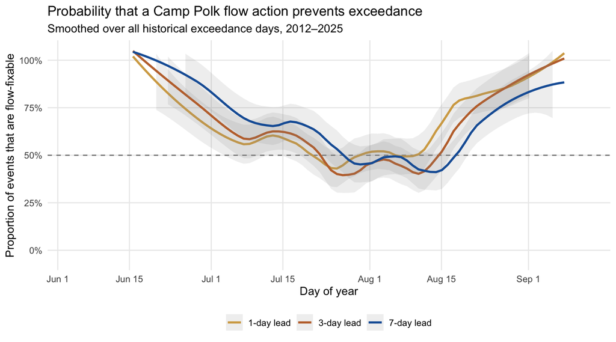

**Figure 8.** Smoothed probability that a flow action can prevent an RM 8.5 7DADM exceedance

```r
sweep_results |>
  mutate(lead_f = factor(paste0(lead_days, "-day lead"),
                         levels = c("1-day lead", "3-day lead", "7-day lead"))) |>
  ggplot(aes(x = julian, y = as.integer(fixable), color = lead_f)) +
  geom_hline(yintercept = 0.5, linetype = "dashed", color = "grey50") +
  geom_smooth(method = "loess", span = 0.4, se = TRUE, alpha = 0.15) +
  scale_color_manual(
    values = c("1-day lead" = "#D4A853", "3-day lead" = "#C07038", "7-day lead" = "#185FA5"),
    name = NULL
  ) +
  scale_x_continuous(
    breaks = c(152, 166, 182, 196, 213, 227, 244),
    labels = c("Jun 1", "Jun 15", "Jul 1", "Jul 15", "Aug 1", "Aug 15", "Sep 1"),
    limits = c(155, 255)
  ) +
  scale_y_continuous(labels = scales::percent, limits = c(-0.05, 1.05)) +
  labs(title    = "Probability that a Camp Polk flow action prevents exceedance",
       subtitle = "Smoothed over all historical exceedance days, 2012–2025",
       x = "Day of year", y = "Proportion of events that are flow-fixable") +
  theme_minimal(base_size = 12) +
  theme(panel.grid.minor = element_blank(), legend.position = "bottom")
```

Two patterns emerge from the historical record:

- **Early-season exceedances** are more often flow-fixable. Air temperatures are moderate enough that additional cool water from Camp Polk can offset thermal loading at RM 8.5.
- **Peak-summer exceedances** are increasingly atmosphere-dominated. During the hottest periods, no Camp Polk flow within the historical range can prevent exceedance — the thermal signal is driven by air temperature and solar radiation, not hydrology.

## 6. The Actionable Lead-Time Window

Flow-fixability is necessary but not sufficient — the decision also has to happen early enough. This section asks: **for each historical exceedance, how far in advance does a flow action need to start to still be effective?**

```r
lead_windows <- sweep_results |>
  group_by(exceedance_date, julian, year) |>
  summarise(
    max_fixable_lead = if (any(fixable)) max(lead_days[fixable]) else 0L,
    any_fixable      = any(fixable),
    min_threshold    = min(threshold_flow, na.rm = TRUE),
    .groups          = "drop"
  ) |>
  mutate(
    window_label = case_when(
      max_fixable_lead == 7 ~ "Fixable: action needed ≥7 days prior",
      max_fixable_lead == 3 ~ "Fixable: action needed ≥3 days prior",
      max_fixable_lead == 1 ~ "Fixable: action needed 1 day prior",
      TRUE                  ~ "Atmosphere-dominated: no flow achieves compliance"
    ),
    window_label = factor(window_label, levels = c(
      "Fixable: action needed ≥7 days prior",
      "Fixable: action needed ≥3 days prior",
      "Fixable: action needed 1 day prior",
      "Atmosphere-dominated: no flow achieves compliance"
    ))
  )
```

Table 4. Distribution of historical exceedance events by the latest forecast lead at which a Camp Polk flow action is predicted to achieve compliance.

| Actionable window | Exceedance events | % |
| --- | --- | --- |
| Fixable: action needed ≥7 days prior | 366 | 61.1% |
| Fixable: action needed ≥3 days prior | 57 | 9.5% |
| Fixable: action needed 1 day prior | 37 | 6.2% |
| Atmosphere-dominated: no flow achieves compliance | 139 | 23.2% |

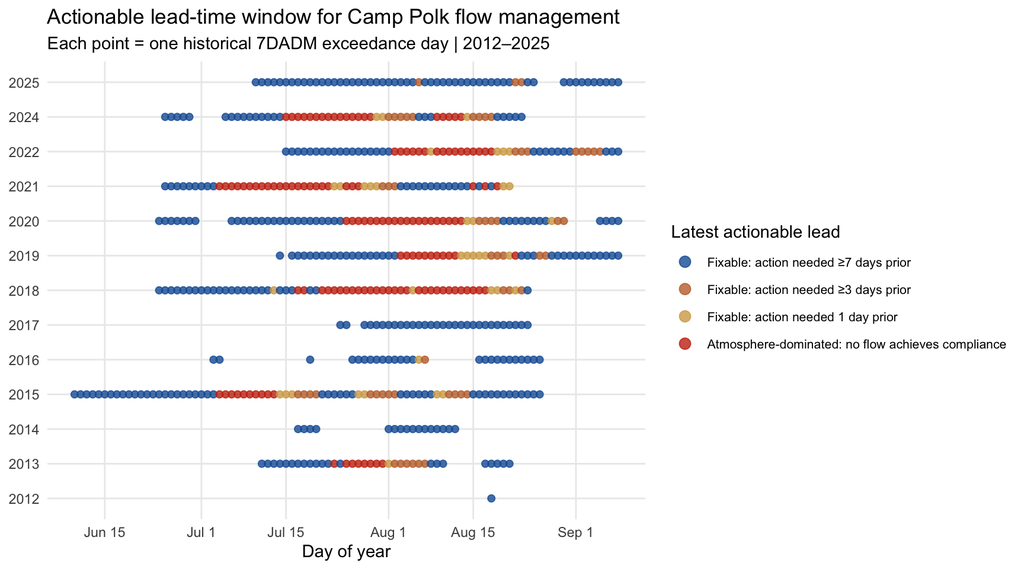

**Figure 9.** Each historical exceedance day plotted by calendar date and year. Color shows the latest forecast lead at which a flow action is still predicted to achieve compliance. Atmosphere-dominated events (red) cluster in the peak summer period; events manageable with a 7-day lead (blue) are more common earlier in the season.

```r
window_colors <- c(
  "Fixable: action needed ≥7 days prior"              = "#185FA5",
  "Fixable: action needed ≥3 days prior"              = "#C07038",
  "Fixable: action needed 1 day prior"                = "#D4A853",
  "Atmosphere-dominated: no flow achieves compliance" = "#C93312"
)

ggplot(lead_windows, aes(x = julian, y = factor(year), color = window_label)) +
  geom_point(size = 1.8, alpha = 0.8) +
  scale_color_manual(values = window_colors, name = "Latest actionable lead",
                     guide = guide_legend(override.aes = list(size = 3))) +
  scale_x_continuous(
    breaks = c(152, 166, 182, 196, 213, 227, 244),
    labels = c("Jun 1", "Jun 15", "Jul 1", "Jul 15", "Aug 1", "Aug 15", "Sep 1")
  ) +
  labs(title    = "Actionable lead-time window for Camp Polk flow management",
       subtitle = "Each point = one historical 7DADM exceedance day | 2012–2025",
       x = "Day of year", y = NULL) +
  theme_minimal(base_size = 11) +
  theme(panel.grid.minor = element_blank(), legend.position = "right",
        legend.text = element_text(size = 8))
```

## Supplementary: Discharge Requirements for Temperature Target Achievement

For each calendar day across the warm season (June 1 – September 30), this section asks: **what is the minimum Camp Polk discharge that would hold RM 8.5 7DADM at or below 20°C, given different air temperature conditions?**

Three scenarios are constructed from the historical distribution of daily maximum and minimum air temperatures near Camp Polk. Each scenario applies the same exceedance probability to both Tmax and Tmin, defining a self-consistent hot, typical, or cool summer day.

Table S1. Air temperature scenarios for the discharge requirements analysis.

| Scenario | Air temp percentile used | Exceedance probability | Interpretation |
| --- | --- | --- | --- |
| Warm | 75th | 25% | Hot conditions — only 25% of historical days are warmer |
| Median | 50th | 50% | Typical summer conditions |
| Cold | 25th | 75% | Cool conditions — 75% of historical days are warmer |

The solid line in the figure below shows the historical median Camp Polk flow (Q50) — what has typically been available on each day. Where a scenario’s dashed line rises above Q50, meeting the temperature target under those conditions would require flows greater than historically typical. The 3-day forecast lead RF model is used for all predictions, with non-flow variables (cloud cover, prior-day RM 8.5 7DADM, Camp Polk water temperature) held at their climatological medians for each day of year.

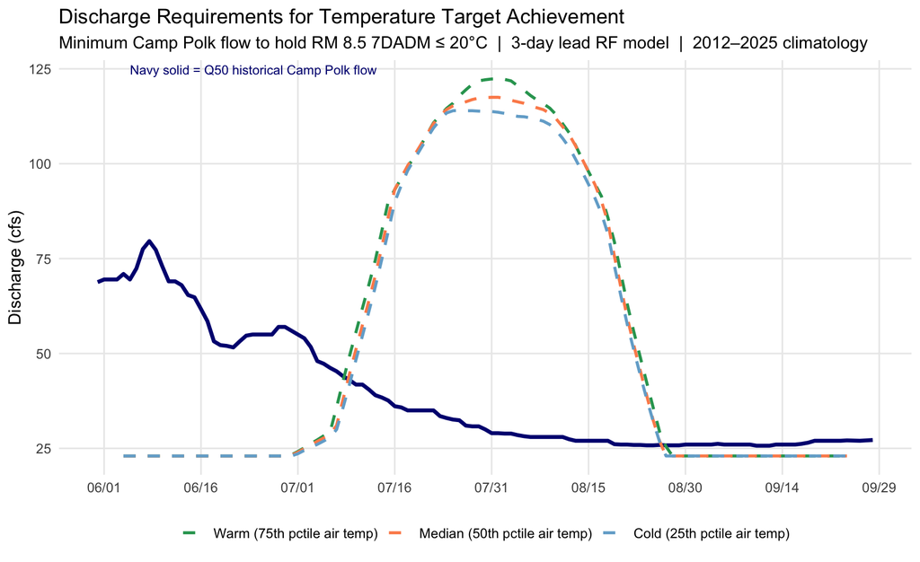

**Figure S1.** Minimum Camp Polk discharge required to hold RM 8.5 7DADM at or below 20°C on each day of the warm season, under three air temperature scenarios (dashed colored lines). The solid navy line is the historical median Camp Polk flow (Q50). When a dashed line rises above Q50, meeting the temperature target under those air temperature conditions would require flows greater than historically typical. Days where no flow within the observed range achieves the target are omitted. RF model: 3-day forecast lead; all non-flow variables held at climatological medians.

```r
date_ref <- as.Date("2024-01-01")

scen_colors_supp <- c(
  "Warm (75th pctile air temp)"   = "#2ca25f",
  "Median (50th pctile air temp)" = "#fc8d59",
  "Cold (25th pctile air temp)"   = "#74add1"
)

q50_plot_supp <- q50_supp |>
  mutate(date_plot = date_ref + julian - 1)

thresh_plot_supp <- thresh_results_supp |>
  mutate(
    date_plot = date_ref + julian - 1,
    label = factor(label, levels = c(
      "Warm (75th pctile air temp)",
      "Median (50th pctile air temp)",
      "Cold (25th pctile air temp)"
    ))
  )

ggplot() +
  geom_line(data = q50_plot_supp,
            aes(x = date_plot, y = q50),
            color = "navy", linewidth = 1.3) +
  geom_line(data = thresh_plot_supp,
            aes(x = date_plot, y = threshold_smooth, color = label),
            linetype = "dashed", linewidth = 1.0, na.rm = TRUE) +
  scale_color_manual(values = scen_colors_supp, name = NULL) +
  scale_x_date(
    breaks = as.Date(c("2024-06-01", "2024-06-16", "2024-07-01", "2024-07-16",
                       "2024-07-31", "2024-08-15", "2024-08-30", "2024-09-14",
                       "2024-09-29")),
    date_labels = "%m/%d"
  ) +
  annotate("text", x = as.Date("2024-06-05"), y = Inf,
           label = "Navy solid = Q50 historical Camp Polk flow",
           hjust = 0, vjust = 1.5, color = "navy", size = 3.2) +
  labs(
    title    = "Discharge Requirements for Temperature Target Achievement",
    subtitle = paste0("Minimum Camp Polk flow to hold RM 8.5 7DADM ≤ ", target_C,
                      "°C  |  3-day lead RF model  |  2012–2025 climatology"),
    x = NULL, y = "Discharge (cfs)"
  ) +
  theme_minimal(base_size = 12) +
  theme(panel.grid.minor = element_blank(), legend.position = "bottom")
```

## Summary

Three operational takeaways:

1. **Flow actions are most useful before mid-July.** After roughly Julian day 200 (July 19), atmospheric conditions frequently dominate regardless of Camp Polk releases. Expecting flow management to hold compliance during the hottest weeks is often unrealistic.
2. **Earlier is cheaper.** For events where flow management can work, acting 7 days in advance typically requires less flow than waiting until 3 days prior — because the 7-day average has more time to be influenced. The required increase grows the longer the decision is delayed.
3. **The window closes fast.** Across historical exceedances, a meaningful fraction are fixable at the 7-day lead but not the 1-day lead. A forecast that shows an impending exceedance should trigger an immediate decision, not a wait-and-see approach.

## RF Model Uncertainty: Flow–Temperature Curve with Tree-Level Confidence Band

The plot below shows the 1-day lead RF model’s predicted RM 8.5 7DADM as a function of Camp Polk flow under median July conditions (DOY 197, 50th-percentile air temperature, climatological cloud and upstream temperature). The shaded band is ±1.96 × SD of individual tree predictions — the spread across the 500 trees in the forest, which captures how much the model’s individual estimators disagree at each flow level.

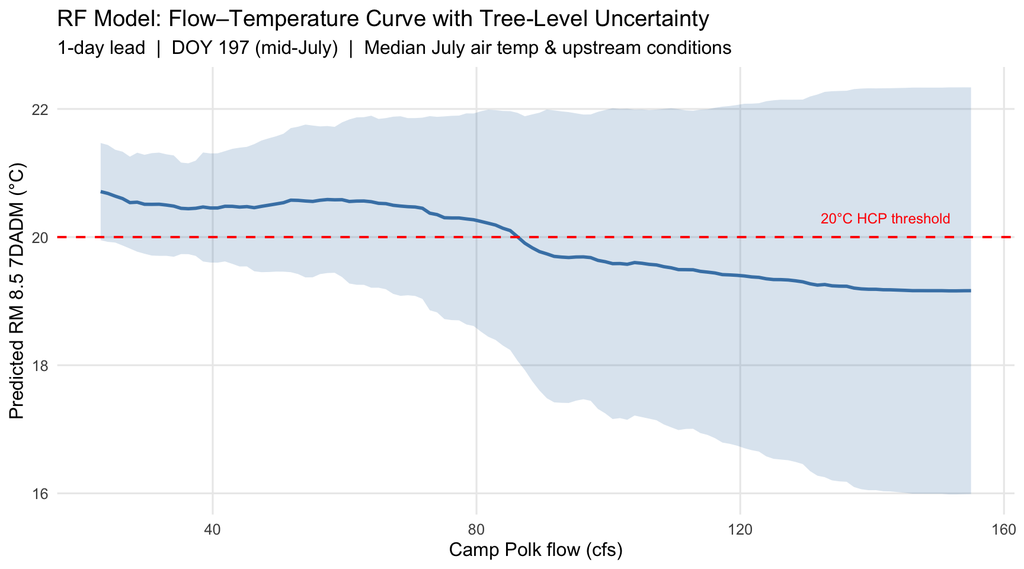

**Figure S2.** Predicted RM 8.5 7DADM (1-day lead RF model) vs. Camp Polk flow under median July conditions. Shaded band = ±1.96 × SD of individual tree predictions. Dashed red line = 20°C HCP threshold.

```r
rf_lead1 <- readRDS(file.path(model_dir, "rm85_rf_7dadm_lead1.rds"))

jd_ref <- 197  # mid-July reference day

# July median conditions computed directly from raw data
jul_air_max <- median(
  all_historical_forecasts$value[
    all_historical_forecasts$variable == "temperature_2m_max" &
    month(all_historical_forecasts$valid_date) == 7],
  na.rm = TRUE)

jul_air_min <- median(
  all_historical_forecasts$value[
    all_historical_forecasts$variable == "temperature_2m_min" &
    month(all_historical_forecasts$valid_date) == 7],
  na.rm = TRUE)

jul_cloud <- median(
  all_historical_forecasts$value[
    all_historical_forecasts$variable == "cloud_cover_mean" &
    month(all_historical_forecasts$valid_date) == 7],
  na.rm = TRUE)

jul_cp_7dadm <- median(
  camp_polk_temperature_historical$temperature[
    camp_polk_temperature_historical$statistic == "7DADM" &
    month(as.Date(camp_polk_temperature_historical$date)) == 7],
  na.rm = TRUE)

jul_dadm_m1 <- median(
  rm85_dadm_base$dadm_7[month(rm85_dadm_base$date) == 7],
  na.rm = TRUE)

obs_flow_ref <- median(
  camp_polk_flow_historical$flow_cfs[month(camp_polk_flow_historical$date) == 7],
  na.rm = TRUE)

sweep_flows <- seq(
  quantile(camp_polk_flow_historical$flow_cfs, 0.05, na.rm = TRUE),
  quantile(camp_polk_flow_historical$flow_cfs, 0.95, na.rm = TRUE),
  length.out = 120
)

cp_7dadm_adj <- cp_temp_delta(jul_cp_7dadm, sweep_flows, obs_flow_ref)

sweep_df <- data.frame(
  cp_flow_mean = sweep_flows,
  cp_7dadm     = cp_7dadm_adj,
  Julian       = jd_ref,
  air_max      = jul_air_max,
  air_min      = jul_air_min,
  cloud_pct    = jul_cloud,
  cp_flow_m1   = sweep_flows,
  cp_7dadm_m1  = cp_7dadm_adj,
  air_max_m1   = jul_air_max,
  air_min_m1   = jul_air_min,
  dadm_m1      = jul_dadm_m1
)

preds_all <- predict(rf_lead1, newdata = sweep_df, predict.all = TRUE)

tibble(
  flow     = sweep_flows,
  pred     = preds_all$aggregate,
  se       = apply(preds_all$individual, 1, sd),
  ci_lower = pred - 1.96 * se,
  ci_upper = pred + 1.96 * se
) |>
  ggplot(aes(x = flow)) +
  geom_ribbon(aes(ymin = ci_lower, ymax = ci_upper), alpha = 0.2, fill = "steelblue") +
  geom_line(aes(y = pred), color = "steelblue", linewidth = 1.0) +
  geom_hline(yintercept = 20, linetype = "dashed", color = "red", linewidth = 0.7) +
  annotate("text", x = max(sweep_flows) * 0.98, y = 20.3,
           label = "20°C HCP threshold", hjust = 1, size = 3.2, color = "red") +
  labs(
    title    = "RF Model: Flow–Temperature Curve with Tree-Level Uncertainty",
    subtitle = paste0("1-day lead  |  DOY ", jd_ref, " (mid-July)  |  Median July air temp & upstream conditions"),
    x        = "Camp Polk flow (cfs)",
    y        = "Predicted RM 8.5 7DADM (°C)"
  ) +
  theme_minimal(base_size = 12) +
  theme(panel.grid.minor = element_blank())
```